# Content-based Movie Recommender

## 1. Erzeugung von Film- & Nutzerprofilen

### 1.1. MovieLense Daten einlesen

```r
data("MovieLense")
MovieLense
```

```
## 943 x 1664 rating matrix of class 'realRatingMatrix' with 99392 ratings.
```

### 1.2. Binäre User-Liked-Items Matrix für alle Nutzer erzeugen.

```r
########### Param ##########
MINIMUM_RATING = 4
##############################

MovieLense_binary <- recommenderlab::binarize(x = MovieLense, minRating = MINIMUM_RATING)

# Test
check_binary_matrix <- test_that(
  "Check binary matrix", {
    expect_equal(class(as(MovieLense_binary, "matrix")[1]), "logical")
  }
)
```

```
## Test passed
```

### 1.3. Dimension der User-Liked-Items Matrix prüfen und ausgeben.

```r
dim(MovieLense_binary)
```

```
## [1]  943 1664
```

```r
MovieLense_binary_matrix = as(MovieLense_binary, "matrix")
```

### 1.4. Movie-Genre Matrix für alle Filme erzeugen.

```r
movie_genre <- MovieLenseMeta %>%
  dplyr::select(-c(url, year))
head(movie_genre)
```

|  | title | unknown | Action | Adventure | Animation | Children's | Comedy | Crime | Documentary | Drama | Fantasy | Film-Noir | Horror | Musical | Mystery | Romance | Sci-Fi | Thriller | War | Western |
| --- | --- | --- | --- | --- | --- | --- | --- | --- | --- | --- | --- | --- | --- | --- | --- | --- | --- | --- | --- | --- |
| 1 | Toy Story (1995) | 0 | 0 | 0 | 1 | 1 | 1 | 0 | 0 | 0 | 0 | 0 | 0 | 0 | 0 | 0 | 0 | 0 | 0 | 0 |
| 2 | GoldenEye (1995) | 0 | 1 | 1 | 0 | 0 | 0 | 0 | 0 | 0 | 0 | 0 | 0 | 0 | 0 | 0 | 0 | 1 | 0 | 0 |
| 3 | Four Rooms (1995) | 0 | 0 | 0 | 0 | 0 | 0 | 0 | 0 | 0 | 0 | 0 | 0 | 0 | 0 | 0 | 0 | 1 | 0 | 0 |
| 4 | Get Shorty (1995) | 0 | 1 | 0 | 0 | 0 | 1 | 0 | 0 | 1 | 0 | 0 | 0 | 0 | 0 | 0 | 0 | 0 | 0 | 0 |
| 5 | Copycat (1995) | 0 | 0 | 0 | 0 | 0 | 0 | 1 | 0 | 1 | 0 | 0 | 0 | 0 | 0 | 0 | 0 | 1 | 0 | 0 |
| 6 | Shanghai Triad (Yao a yao yao dao waipo qiao) (1995) | 0 | 0 | 0 | 0 | 0 | 0 | 0 | 0 | 1 | 0 | 0 | 0 | 0 | 0 | 0 | 0 | 0 | 0 | 0 |

### 1.5. Dimension der Movie-Genre Matrix prüfen und ausgeben.

```r
dim(movie_genre)
```

```
## [1] 1664   20
```

**Beschreibung**

Diese Dimensionen ergeben Sinn; Wir haben 1664 Filme und 19 Genres im Datensatz (eine Spalte wird für den Filmnamen gebraucht).

### 1.6. Anzahl unterschiedlicher Filmprofile bestimmen und visualisieren.

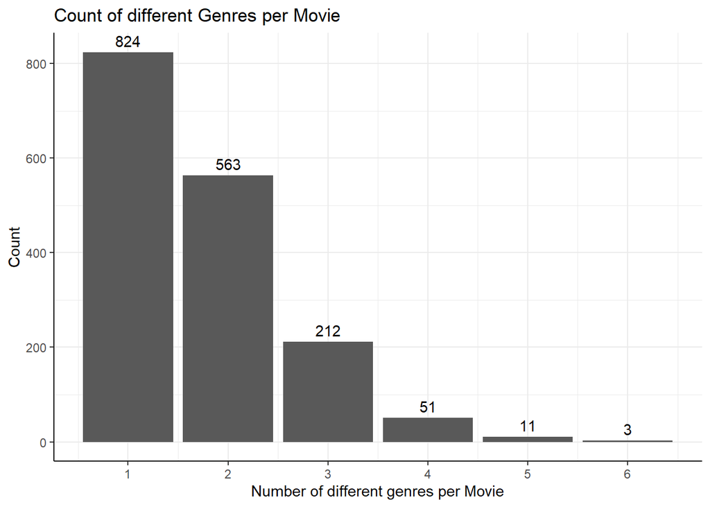

```r
number_of_genres <- movie_genre %>%
  dplyr::select(-title) %>%
  rowSums()

ggplot(data.frame(data.frame(number_of_genres)), aes(number_of_genres)) +
  geom_bar() +
  ggplot2::theme_bw() +
  ggplot2::xlab("Number of different genres per Movie") +
  ggplot2::ylab("Count") +
  ggplot2::ggtitle('Count of different Genres per Movie') +
  ggplot2::theme(panel.border = element_blank(),
                 axis.line = element_line(colour = "black")) +
  ggplot2::scale_x_continuous(breaks = seq(1, 6, by = 1)) +
  geom_text(aes(label = ..count..), stat = "count", vjust = -0.5)
```

**Beschreibung:**

```r
 # Test that the number of Genres are consistent between objects.
check_dims_genres <- test_that(
  "Check dims of movie_genre fit with new generated number_of_genres", {
    expect_equal(dim(movie_genre)[1], nrow(data.frame(data.frame(number_of_genres))))
     }
)
```

```
## Test passed
```

```r
tmp <- tidyr::pivot_longer(data = movie_genre, cols = 2:dim(movie_genre)[[2]], names_to = "genre")

tmp <- tmp[tmp$value > 0, c("title", "genre")] %>%
   group_by(title) %>%
   mutate(combinations = paste0(genre, collapse="-")) %>%
   distinct(title, .keep_all = TRUE) %>%
   select(-genre)

combinations <- tmp %>%
 dplyr::group_by(combinations) %>%
 dplyr::count() %>%
 dplyr::arrange(n)

total_unique_combinations <- length(unique(combinations$combinations))
total_unique_combinations
```

```
## [1] 216
```

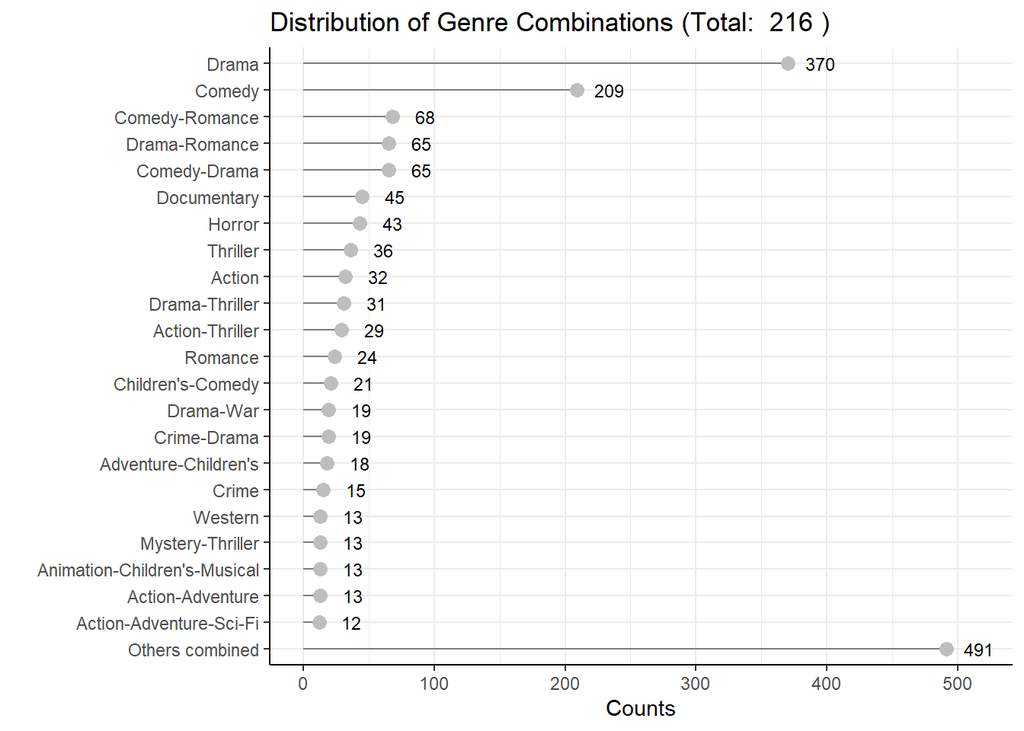

```r
all_combinations <- combinations

combinations$combinations[combinations$n <= 11] <- "Others combined"
combinations <-combinations %>% group_by(combinations) %>% summarise(n = sum(n))
combinations <- combinations[order(combinations$n),]
combinations <- rbind(combinations[(nrow(combinations)),], combinations[-(nrow(combinations)),])

# use helper file to transform
tmp <- turn_into_wide(df = tmp)

combinations$combinations <- factor(combinations$combinations, levels = combinations$combinations)

ggplot2::ggplot(combinations, ggplot2::aes(x = n, y = combinations, label = n)) +
  ggplot2::geom_segment(ggplot2::aes(x = 0, y = combinations, xend = n, yend = combinations), color = "grey50") +
  ggplot2::geom_point(size=3, color = "grey") +
  ggplot2::geom_text(nudge_x = 25, size = 3) +
  ggplot2::theme_bw() +
  ggplot2::xlab("Counts") +
  ggplot2::ylab("") +
  ggplot2::ggtitle(paste("Distribution of Genre Combinations (Total: ", total_unique_combinations, ")")) +
  ggplot2::theme(panel.border = element_blank(),
                 axis.line = element_line(colour = "black"))
```

**Beschreibung:**

Der Plot zeigt die Anzahl der Genres in unserem Datensatz. Ingesamten kommen Filme mit “Drama” und “Comedy” als Genre am häufigsten vor. Falls eine Kombination weniger als 12 mal vorkommt, wird diese zusammengefasst als “Others combined”, da sonst der obere Plot aus 216 Kombinationen bestehen wurde.

```r
 # Test
check_dims_genres <- test_that(
  "Check dims of genre matrices fit with new generated wide df", {
    expect_equal(total_unique_combinations, dim(tmp)[2]-1)
     }
)
```

```
## Test passed
```

### 1.7. User-Genre-Profil Matrix mit Nutzerprofilen im Genre-Vektorraum erzeugen.

```r
########## Param ##########
NORMALIZED_BY_VIEWS <- FALSE

###########################
# Convert both into matrices
user_movie_mat <- as(MovieLense_binary, "matrix")


movie_genre_mat <- movie_genre %>%
  dplyr::select(-title) %>%
  as.matrix()

# Create user genre profile
if (NORMALIZED_BY_VIEWS){
  user_genre_mat <- ((user_movie_mat / as.vector(rowSums(user_movie_mat))) %*% movie_genre_mat)
} else {
  user_genre_mat <- user_movie_mat %*% movie_genre_mat
}


# Test
check_both_matrices <- test_that(
  "Check matrices types", {
    expect_equal(class(user_movie_mat), class(movie_genre_mat))
  }
)
```

```
## Test passed
```

```r
check_mat_dim <- test_that(
  "Check mat dims", {
    expect_equal(dim(user_movie_mat)[2], dim(movie_genre)[1])
  }
)
```

```
## Test passed
```

```r
check_mat_dim_out <- test_that(
  "Check mat dims output", {
    expect_equal(dim(user_genre_mat), c(dim(user_movie_mat)[1], dim(movie_genre_mat)[2]))
  }
)
```

```
## Test passed
```

Achtung! Die Werte können, trotz Normalisierung der Views, grösser als 1 sein, da gewisse Filme über mehrere Genres verfügen.

### 1.8. Dimension der User-Genre-Profil Matrix prüfen und ausgeben.

```r
dim(user_genre_mat)
```

```
## [1] 943  19
```

**Beschreibung**

Die Matrix zeigt über die Reihen hinweg alle User und über die Spalten hinweg alle erzeugten Scores bezüglich ihrer Relation zu einem bestimmten Genre. Wir haben 943 User und 19 Genres.

### 1.9. Anzahl unterschiedlicher Nutzerprofile bestimmen, wenn Stärke der GenreKombination (a) vollständig bzw. (b) nur binär berücksichtigt wird.

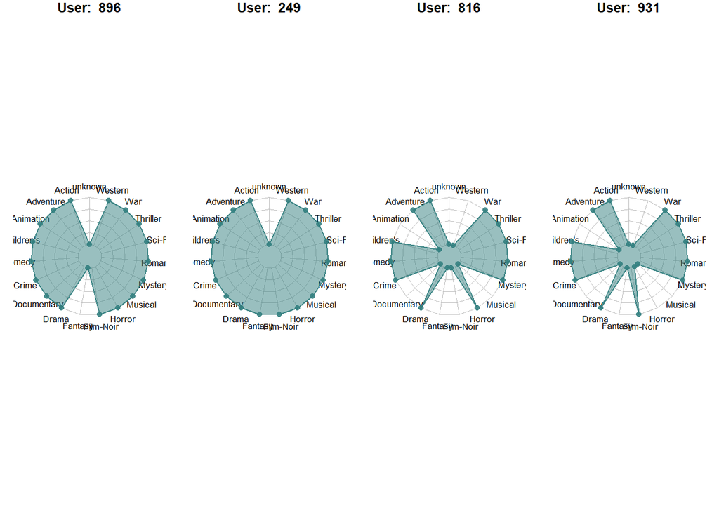

```r
BINARY_THRESHOLD <- 0

# Create Binaray User-Genre Matrix
user_genre_mat_binary <- ifelse(user_genre_mat > BINARY_THRESHOLD, 1, 0)
random_idx <- sample(seq(1, dim(user_genre_mat_binary)[[1]]),
                        size = 4)


plot_user_profiles(user_genre_mat_binary, user_idx = random_idx,
                    sample_size = 5, n_cols = 5)
```

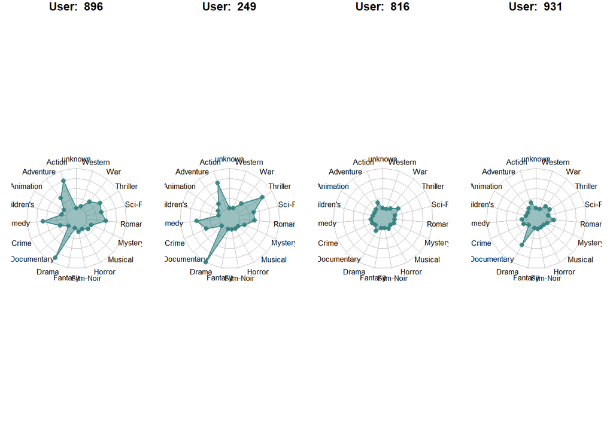

```r
plot_user_profiles(user_genre_mat, user_idx = random_idx,
                    sample_size = 5, n_cols = 5)
```

**Beschreibung:**

Die beiden Plots unterscheiden sich stark in ihren Wertebereichen. Der Wertebereich des binärisierten Plots reicht bei jedem Nutzer von 0 bis nach 1. Die Grafik des binären Plots verändert sich, falls der BINARY_THRESHOLD angepasst wird. Der Plot mit den normalen Ratings sieht wie erwartet aus. Die Spiderdiagramme zeigen die stärkste Ausprägung meistens bei dem Genre Drama, da es das meistgesehene Genre im Datensatz ist und auch am meisten Filme unter diesem Genre vorkommen.

## 2. Ähnlichkeit von Nutzern und Filmen

### 2.1. Cosinus-Ähnlichkeit zwischen User-Genre- und Movie-Genre-Matrix berechnen.

```r
# Test
similarity_matrix <- calc_cosine_similarity(user_genre_mat, movie_genre_mat)

# Check similarity results with package coop
check_similarity_results <- test_that(
  "Check mat dims with users", {
    expect_equal(similarity_matrix[1,1], coop::cosine(user_genre_mat[1, ] ,movie_genre_mat[1, ]) )
  }
)
```

```
## Test passed
```

`user_gerne_mat` beinhaltet, welche Genre ein User gern hat und `movie_gerne_mat`, welche Genre ein Film hat.

### 2.2. Dimension der Matrix der Cosinus-Ähnlichkeiten von Nutzern und Filmen prüfen und ausgeben.

```r
dim(similarity_matrix)
```

```
## [1]  943 1664
```

```r
# Run Tests on Dimensionality fo Similarity Matrix
check_mat_dim <- test_that(
  "Check mat dims with users", {
    expect_equal(dim(similarity_matrix)[1], dim(user_genre_mat)[1])
    expect_equal(dim(similarity_matrix)[2], dim(movie_genre_mat)[1])
  }
)
```

```
## Test passed
```

### 2.3. 5-Zahlen Statistik für Matrix der Cosinus-Ähnlichkeiten prüfen uns ausgeben.

```r
summary(as.numeric(similarity_matrix))
```

```
##    Min. 1st Qu.  Median    Mean 3rd Qu.    Max.    NA's
##  0.0000  0.2300  0.4070  0.4098  0.5919  0.9768    1664
```

**Beschreibung**

Interessant sind die 1664 NA’s. Diese kommen vom User `685`. Wir sehen, dass der User `685` keine Filme als gut bewertet hat und somit entstehen bei der similarity_matrix für den User `685` nur NA’s, da er keine “Lieblingsgenres” hat. Genau entstehen die NA’s dadurch, dass die Cosine-Similarity mit einem Nullvektor nicht definiert ist, da im Zähler und im Nenner eine 0 steht und 0 durch 0 nicht definiert ist.

```r
user_genre_mat[685,]
```

```
##     unknown      Action   Adventure   Animation  Children's      Comedy
##           0           0           0           0           0           0
##       Crime Documentary       Drama     Fantasy   Film-Noir      Horror
##           0           0           0           0           0           0
##     Musical     Mystery     Romance      Sci-Fi    Thriller         War
##           0           0           0           0           0           0
##     Western
##           0
```

### 2.4. Cosinus-Ähnlichkeiten von Nutzern und Filmen mit Dichteplot visualisieren.

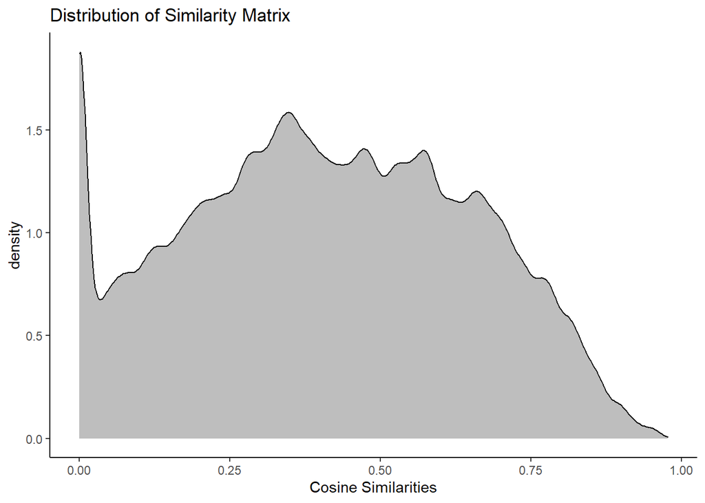

```r
tmp <- as.vector(similarity_matrix)
tmp <- as.data.frame(tmp)

ggplot2::ggplot(data = tmp, aes(x = tmp)) +
  ggplot2::geom_density(fill = "grey", color = "black") +
  ggplot2::labs(title = "Distribution of Similarity Matrix") +
  ggplot2::xlab("Cosine Similarities") +
  theme_classic()
```

**Beschreibung:**

Der Plot zeigt die Verteilung der berechneten Ähnlichkeitsmasse pro User und Film innerhalb des Datensatzes. Man erkennt eine starke Ausprägung der Nullwerte (gar keine Similarity zwischen Nutzer und Filmen). Dies lässt sich mit der These vereinbaren, dass es Nutzer gibt, die fast keine Filme geschaut haben und vice-versa Filme, die fast nie geschaut wurden. Ohne die starke Ausprägung bei der tiefen Cosine Similaritie wäre das Histogram ggf. normalverteilt.

### 2.5. Cosinus-Ähnlichkeiten von Nutzern und Filmen mit Dichteplot für Nutzer “241”, “414”, “477”, “526”, “640” und “710” visualisieren.

```r
user_selection <- similarity_matrix[c(241, 414, 477, 526, 640, 710), ]

user_selection <- as.data.frame(t(user_selection)) %>%
  reshape2::melt(value.name = "similarity")
```

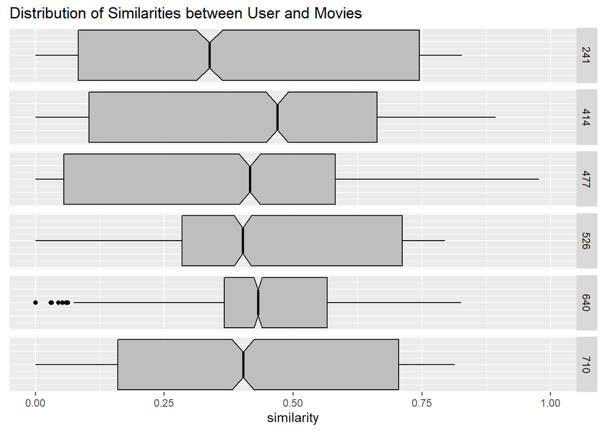

```r
colnames(user_selection) <- c("user", "similarity")

ggplot2::ggplot(data = user_selection, ggplot2::aes(x = similarity)) +
  ggplot2::geom_boxplot(fill="grey", color = "black", notch = TRUE) +
  facet_grid(rows = vars(user)) +
  xlim(0, 1) +
  labs(title = "Distribution of Similarities between User and Movies") +
  theme(axis.title.y=element_blank(),
        axis.text.y=element_blank(),
        axis.ticks.y=element_blank())
```

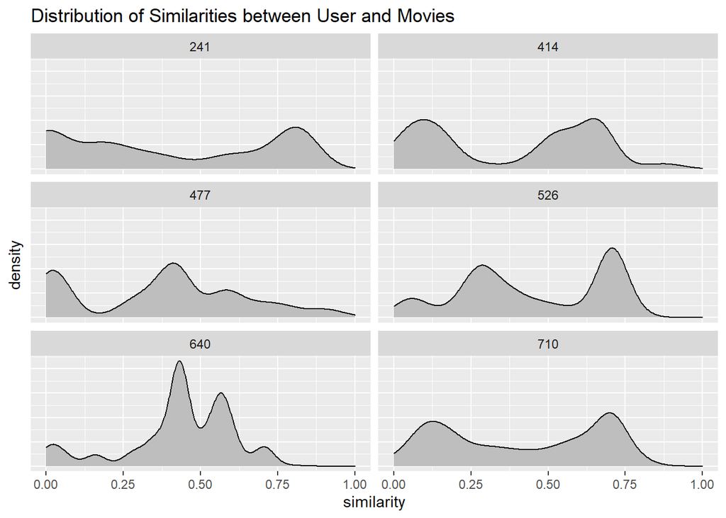

```r
ggplot2::ggplot(data = user_selection, ggplot2::aes(x = similarity)) +
  ggplot2::geom_density(fill="grey", color = "black") +
  facet_wrap(~user, nrow = 3) +
  xlim(0, 1) +
  labs(title = "Distribution of Similarities between User and Movies") +
  ggplot2::ylab("density") +
  theme(axis.text.y=element_blank(),
        axis.ticks.y=element_blank())
```

**Beschreibung:**

## 3. Empfehlbare Filme

### 3.1. Bewertete Filme maskieren, d.h. “Negativabzug” der User-Items Matrix erzeugen, um anschliessend Empfehlungen herzuleiten.

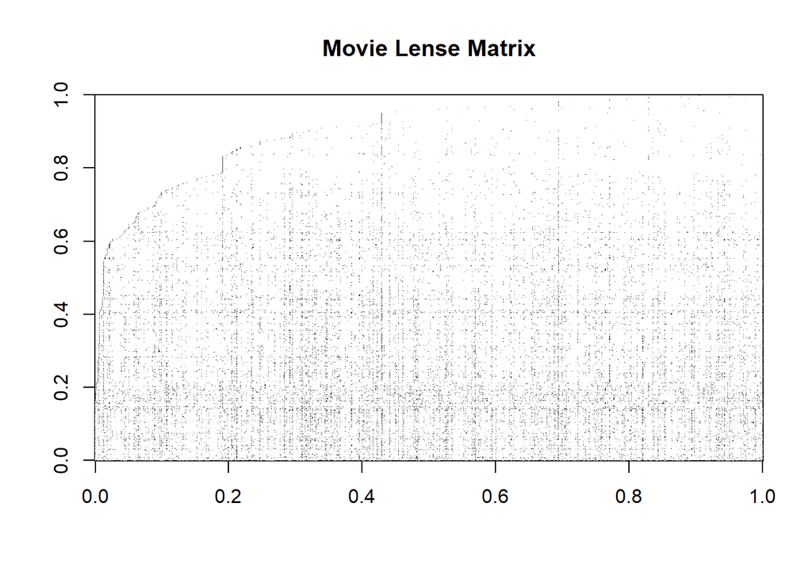

```r
MovieLenseMat <- as(MovieLense, "matrix")
MovieLenseMat_mask <- ifelse(is.na(MovieLenseMat), 1, 0)

image(MovieLenseMat, col = gray.colors(2), main = "Movie Lense Matrix")
```

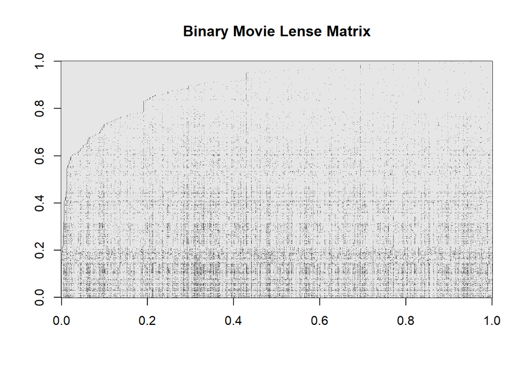

```r
image(MovieLenseMat_mask, col = gray.colors(2), main = "Binary Movie Lense Matrix")
```

**Beschreibung:**

Oben können wir die beiden Matrizen als Bild betrachten: Das Erste ist der normale Movielense-Datensatz und das Zweite ist der “Negativabzug”. Im “Negativabzug” sind alle NA-Werte (Film nicht bewertet/geschaut) eine 1 und alle anderen eine 0. Da der durchschnittliche Nutzer nur wenige Filme bewertet, hat das erste Bild nur wenige Datenpunkte.

### 3.2. Zeilensumme des “Negativabzuges” der User-Items Matrix für die User “5”, “25”, “50” und “150” ausgeben.

```r
SELECTED_USERS = c(5, 25, 50, 150)
###
Mask_sum = MovieLenseMat_mask
Mask_sum = data.frame(Sum = rowSums(Mask_sum))
Mask_sum$User <- factor(row.names(Mask_sum))

### Select users
sum_mask_users = Mask_sum[Mask_sum$User %in% SELECTED_USERS,]
sum_mask_users$User <- factor(sum_mask_users$User, levels = SELECTED_USERS)

#orginal-dimension of the matrix
dim(MovieLense)
```

```
## [1]  943 1664
```

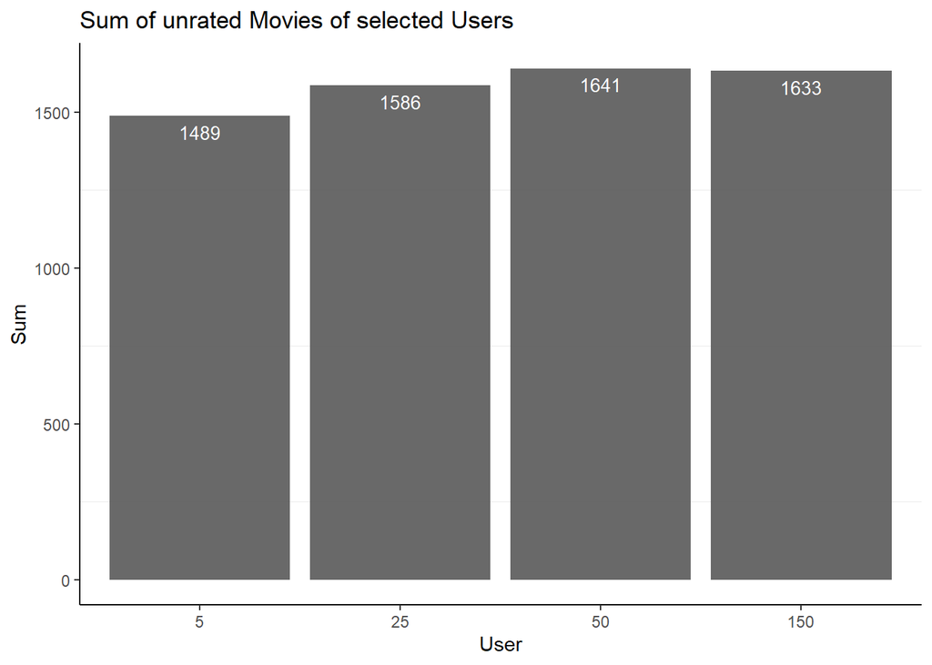

```r
ggplot(data=sum_mask_users, aes(x=User, y=Sum)) +
  ggplot2::geom_bar(stat="identity", alpha = .9) +
  ggplot2::geom_text(aes(label=Sum), vjust=1.6, color="white", size=3.5) +
  ggplot2::ggtitle('Sum of unrated Movies of selected Users') +
  ggplot2::theme_bw() +
  ggplot2::theme(panel.border = element_blank(),
                 panel.grid.major = element_blank(),
                 axis.line = element_line(colour = "black")) +
  ggplot2::ylim(0, max(sum_mask_users$Sum))
```

**Beschreibung:**

Es scheint so, als gäbe es keine grossen Unterschiede zwischen den Nutzern. Das liegt daran, dass wir uns die Filme ansehen, die von den Nutzern nicht bewertet wurden. Da es so viele verschiedene Filme gibt (1664), ist es normal, dass jeder eine so hohe Anzahl an nicht bewerteten Filmen hat. Zum Beispiel können wir sagen, dass der Nutzer `5` die meisten Filme bewertet hat und deshalb die niedrigste Anzahl an nicht bewerteten Filmen aufweist.

### 3.3. 5-Zahlen Statistik der Zeilensumme des “Negativabzuges” der User-Items Matrix bestimmen.

```r
summary(as.numeric(Mask_sum$Sum))
```

```
##    Min. 1st Qu.  Median    Mean 3rd Qu.    Max.
##     929    1516    1600    1559    1632    1645
```

Die Statistik zeigt die wichtigsten Komponenten der Daten Minimum, Q1, Median, Mittelwert, Q3 und Maximum der Daten. Ausserdem sieht man hier auch, dass die Verteilung eher linksschief sein muss, da das Minimum weiter weg vom Q1 und Median ist, als das Maximum vom Q3 und Median.

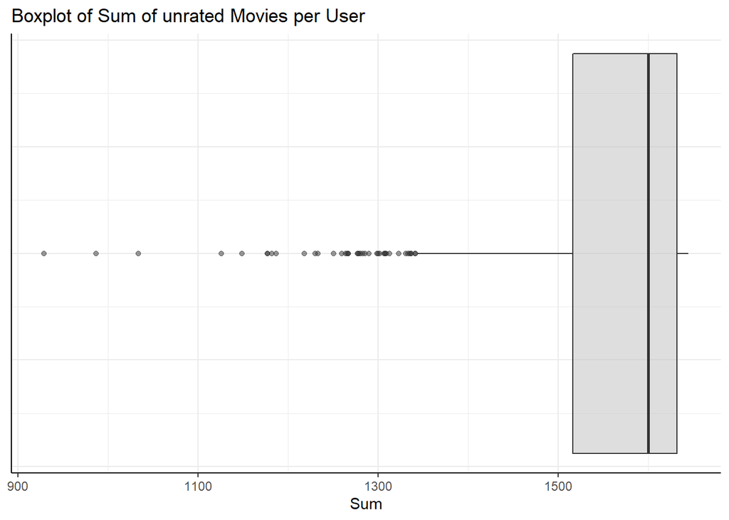

```r
# Horizontal
ggplot(Mask_sum, aes(y=Sum)) +
  ggplot2::geom_boxplot(fill = "grey", alpha = .5) +
  ggplot2::ggtitle('Boxplot of Sum of unrated Movies per User') +
  ggplot2::theme_bw() +
  coord_flip() + theme_bw() +
  theme(axis.text.y=element_blank(),
        axis.ticks.y=element_blank(),
        panel.border = element_blank(),
        axis.line = element_line())
```

**Beschreibung:**

Der Plot unterstützt die Annahmen der statistischen Kennzahlen nochmals. Mit Hilfe der Grafik können wir feststellen, dass wir die meisten Daten um 1600 haben. wir können auch sagen, dass dies eine Zahl ist, die sehr nahe an der maximalen Anzahl von Filmen (1664) liegt. wir haben viele Ausreißer in den unteren Werten. Der Minimalwert liegt bei 929. Es gibt also einen Nutzer, der 929 Filme nicht bewertet hat. Der höchste Wert liegt bei 1645. Das ist sehr verwunderlich, weil wir dachten, dass er bei 1664 liegen würde, weil es immer Leute geben sollte, die nie einen Film bewerten (z.B. neu hinzugefügte User). Aber in diesem Datensatz ist dies nicht der Fall.

## 4. Top-N Empfehlungen

### 4.1. Matrix für Bewertung aller Filme durch element-weise Multiplikation der Matrix der Cosinus-Ähnlichkeiten von Nutzern und Filmen und “Negativabzug” der User-Items Matrix erzeugen.

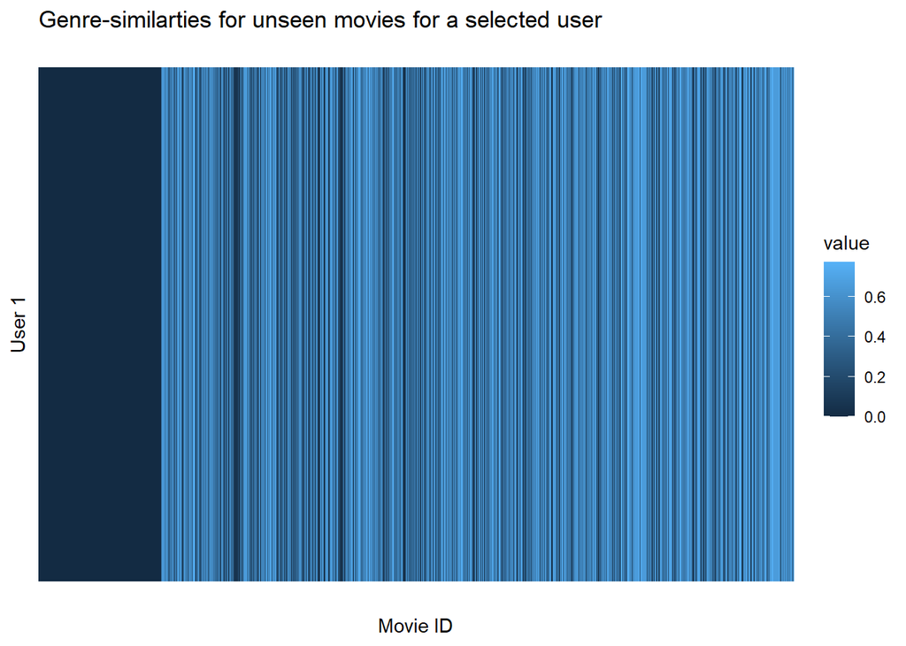

```r
similarity_users <- MovieLenseMat_mask * similarity_matrix

df <- melt(t(similarity_users[1:5,1:5]))

colnames(df) <- c("x", "y", "value")

df <- melt(t(similarity_users[1,]))

colnames(df) <- c("x", "y", "value")
ggplot(df, aes(x = y, y = x, fill = value)) +
  geom_tile() +
  theme(axis.text.x=element_blank(),
        axis.text.y=element_blank(),
        axis.ticks.x=element_blank(),
        axis.ticks.y=element_blank()
        ) +
  ggplot2::ggtitle('Genre-similarties for unseen movies for a selected user') +
  ggplot2::xlab('Movie ID') + ggplot2::ylab("User 1")
```

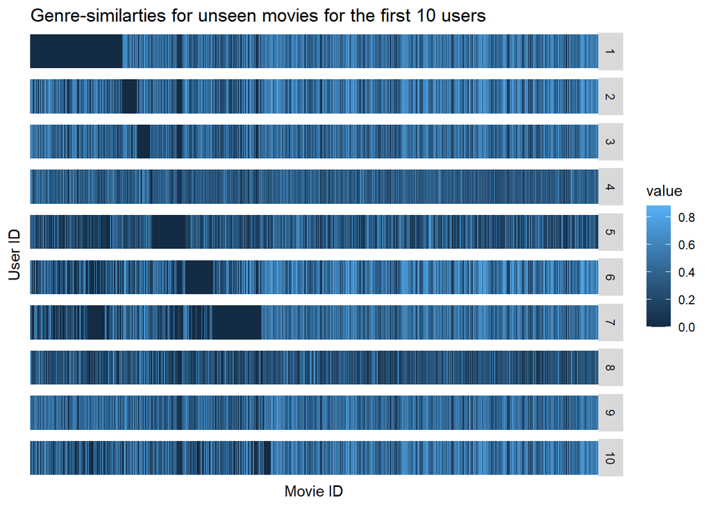

```r
similarity_users_melted <- melt(t(similarity_users))
users_num = c(1,2,3,4,5,6,7,8,9,10)

df1 <- similarity_users_melted[similarity_users_melted$Var2 == 1,]
df1 <- similarity_users_melted[similarity_users_melted$Var2 %in% users_num, ]

colnames(df1) <- c("x", "y", "value")
ggplot(df1, aes(x = x, y = y, fill = value)) +
  geom_tile() +
  theme(axis.text.x=element_blank(),
        axis.text.y=element_blank(),
        axis.ticks.x=element_blank(),
        axis.ticks.y=element_blank()
        ) +
  ggplot2::ggtitle('Genre-similarties for unseen movies for the first 10 users') +
  ggplot2::xlab('Movie ID') +
  ggplot2::ylab('User ID') +
  facet_grid(rows = df1$y, scales = "free")
```

**Beschreibung:**

Wir betrachten hier oben verschiedene Visualisierungen über die Genre-Ähnlichkeiten für ungesehene Filme für verschiedene Nutzer.

In der ersten Grafik sieht man, dass es für den User 1 entweder gar keine Ähnlichkeiten zwischen den Filmen und seinem Profil besteht oder er diese alle gesehen hat und durch den Negativabzug zu 0 wurden. Die weiteren Linien, die aus der Ferne wie ein Barcode aussehen, sind Filme mit einer anderen Recommendation für den User 1. Es könnte also sein, dass der User 1 die Filme nach ID anschaut. Die letzte Abbildung ist eine Übersicht über die ersten 10 Nutzer und alle Genre-Ähnlichkeiten für die ungesehenen Filme. Man kann hier sehen, dass alle User komplett unterschiedliche Empfehlungen erhalten. Im zweiten Plot sieht man User mit einem ähnlichen Verhalten analog zum User 1.

### 4.2. Dimension der Matrix für die Bewertung aller Filme prüfen.

```r
dim(similarity_users)
```

```
## [1]  943 1664
```

**Beschreibung**

Diese Dimensionen der Similarity ergeben Sinn: 943 User, 1664 Filme.

### 4.3. Top-20 Listen pro Nutzer extrahieren.

```r
top_top20_recos <- get_topn_recos(similarity_users_melted, 20)
head(top_top20_recos)
```

|  | Var1 | Var2 | value |
| --- | --- | --- | --- |
| 335 | House of Yes, The (1997) | 1 | 0.7741387 |
| 1129 | Best Men (1997) | 1 | 0.7735659 |
| 508 | Wings of Desire (1987) | 1 | 0.7691763 |
| 513 | Manhattan (1979) | 1 | 0.7691763 |
| 686 | American President, The (1995) | 1 | 0.7691763 |
| 725 | Corrina, Corrina (1994) | 1 | 0.7691763 |

`Var1` entspricht dem `Movie-title`, `Var2` entspricht der `User-ID` und `value` der Similarity.

### 4.4. Länge der Top-20 Listen pro Nutzer prüfen.

```r
#test with a user
top_top20_recos_user_42 <- top_top20_recos[top_top20_recos$Var2 %in% 42, ]

#5-Zahlen Statistik
fivenum(top_top20_recos_user_42$value)
```

```
## [1] 0.6680884 0.6980778 0.7301148 0.7301148 0.7507784
```

**Beschreibung:**

```r
top20_mean_group_size <- top_top20_recos %>%
  group_by(Var2) %>%
  summarise(group_size = n())

expect_equal(all(top20_mean_group_size$group_size == 20), TRUE)
```

**Beschreibung:**

Wie erwartet, besteht die Top20 Liste für jeden User aus 20 Filmen.

### 4.5. Verteilung der minimalen Ähnlichkeit für Top-N Listen für N = 10, 20, 50 und 100 für alle Nutzer visuell vergleichen.

```r
top_n_intervall = c(10, 20, 50, 100)
top_n_col_names = c('1. Top 10', '2. Top 20', '3. Top 50', '4. Top 100')
#create data frame with 0 rows and 5 columns
min_similarity_top_n <- data.frame(matrix(ncol = 1,
                                          nrow = length(row.names(similarity_users))))
#provide column names
colnames(min_similarity_top_n) <- c('User')
min_similarity_top_n$User <- row.names(similarity_users)

for (i in 1:4) {
  top_n_recos = get_topn_recos(similarity_users_melted, top_n_intervall[i])

  min_top_n_recos = top_n_recos %>%
    select(Var2, value) %>%
    group_by(Var2) %>%
    mutate(
    MinSimilarity = min(value, na.rm = T),
    User = min(Var2, na.rm = T)
    ) %>% select(User, MinSimilarity) %>%
    distinct(.keep_all = TRUE)

  min_similarity_top_n[,top_n_col_names[i]] <- min_top_n_recos$MinSimilarity
}
min_similarity_top_n_long <- pivot_longer(min_similarity_top_n,
                                          cols=all_of(top_n_col_names),
                                          names_to='TopN',
                                          values_to='MinSimilarity')
head(min_similarity_top_n_long)
```

| User | TopN | MinSimilarity |
| --- | --- | --- |
| 1 | 1. Top 10 | 0.7691763 |
| 1 | 2. Top 20 | 0.7657912 |
| 1 | 3. Top 50 | 0.7657912 |
| 1 | 4. Top 100 | 0.6624702 |
| 2 | 1. Top 10 | 0.8827167 |
| 2 | 2. Top 20 | 0.8050765 |

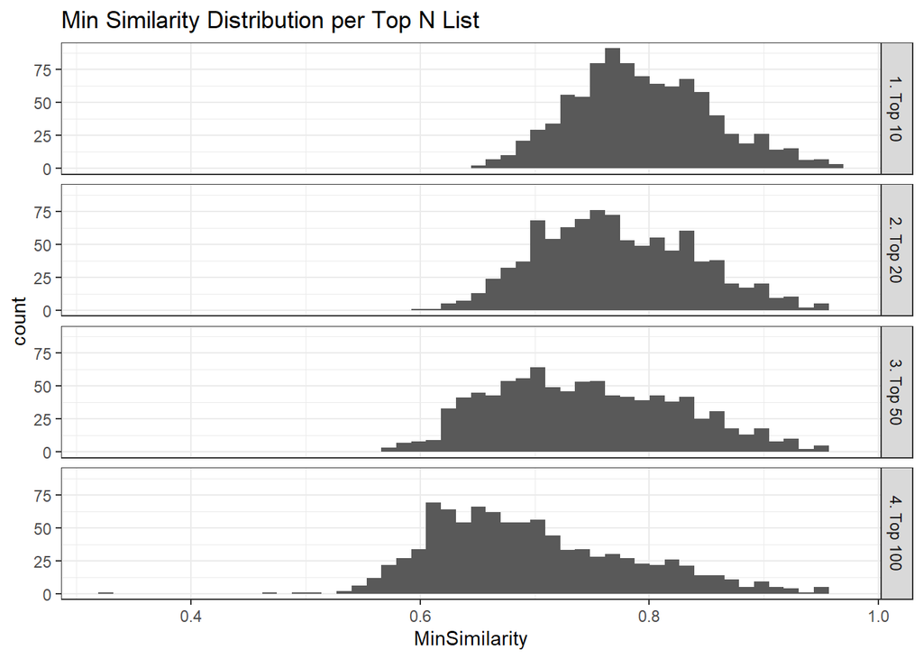

```r
ggplot2::ggplot(min_similarity_top_n_long, ggplot2::aes(x=MinSimilarity)) +
  ggplot2::geom_histogram(bins=50)+
  ggplot2::labs(title = "Min Similarity Distribution per Top N List")+
  ggplot2::facet_grid(TopN ~ .) +
  ggplot2::theme_bw()
```

**Beschreibung:**

Im oberen Plot sehen wir, dass der Modus der Mindest-Similarity abnimmt bei einem grösseren N bei der TopN Liste. Bei der Top100 sehen wir, dass die Mindest-Similarity bis under 0.4 fällt. Das führt wahrscheinlich zu ungeeigneten Empfehlungen. Somit müsste man ggf. das N pro User bestimmen und nicht das selbe N für alle User benutzen.

### 4.6. Top-20 Empfehlungen für Nutzer “5”, “25”, “50” und “150” visuell evaluieren.

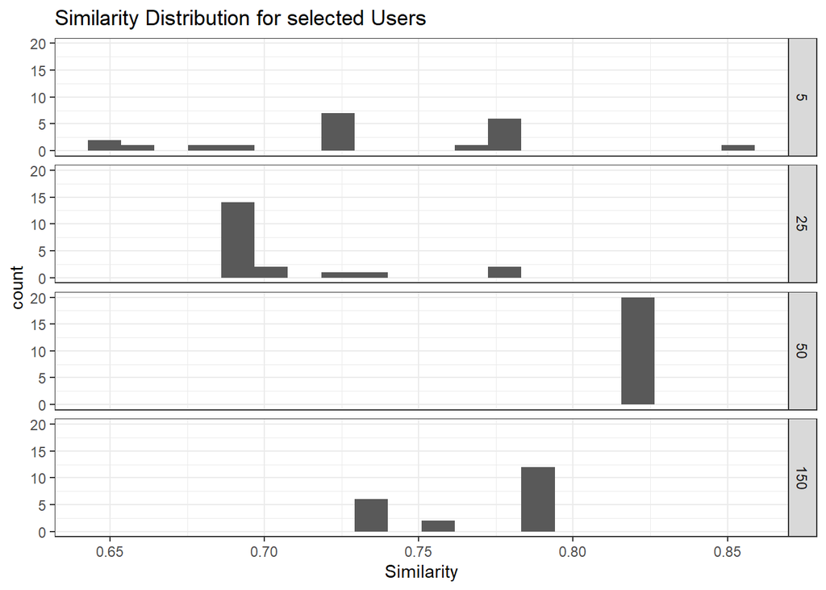

```r
top_top20_recos_users <- top_top20_recos[top_top20_recos$Var2 %in% c(5, 25, 50, 150), ]
top_top20_recos_users$user = top_top20_recos_users$Var2
top_top20_recos_users$Similarity = top_top20_recos_users$value


ggplot2::ggplot(top_top20_recos_users, ggplot2::aes(x=Similarity)) +
  ggplot2::geom_histogram(bins=20)+
  ggplot2::labs(title = "Similarity Distribution for selected Users") +
  ggplot2::facet_grid(user ~ .) +
  ggplot2::theme_bw()
```

**Beschreibung:**

Es ist interessant zu sehen, wie sehr die Top20-Similarity für verschiedene User variiert. Das zeigt uns, dass unser Recommender für verschiedene User verschiedene Empfehlungen macht und zumindest in diesem Aspekt funktioniert.

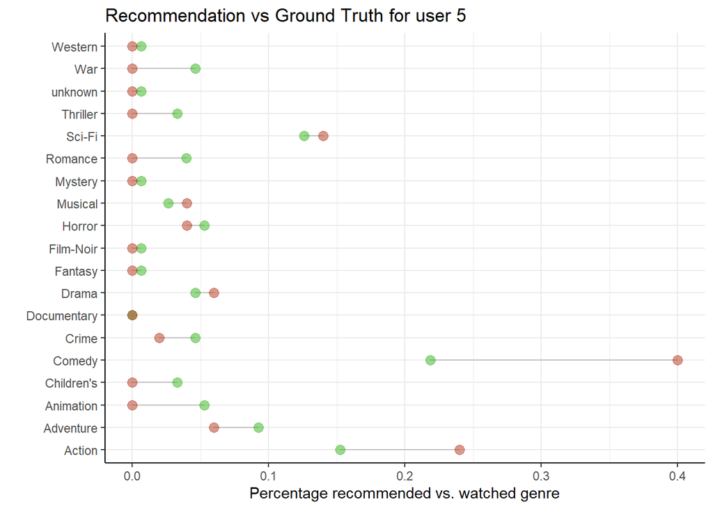

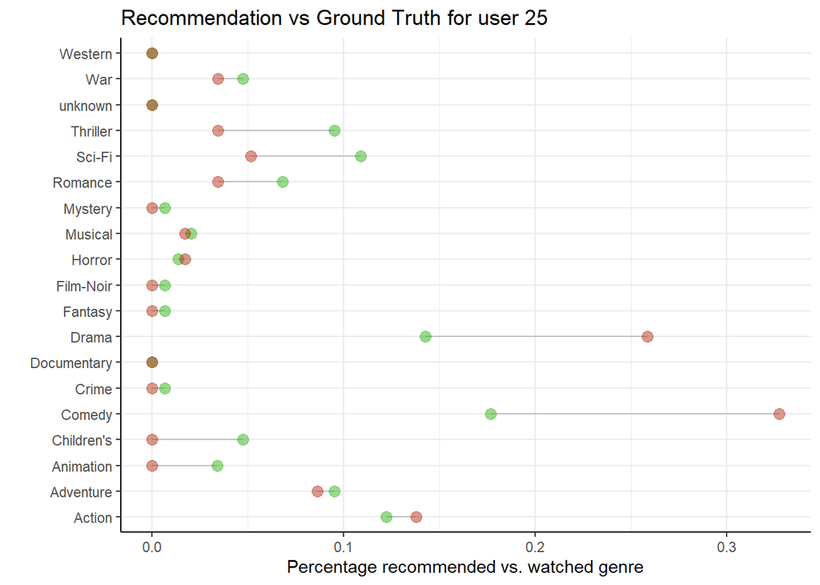

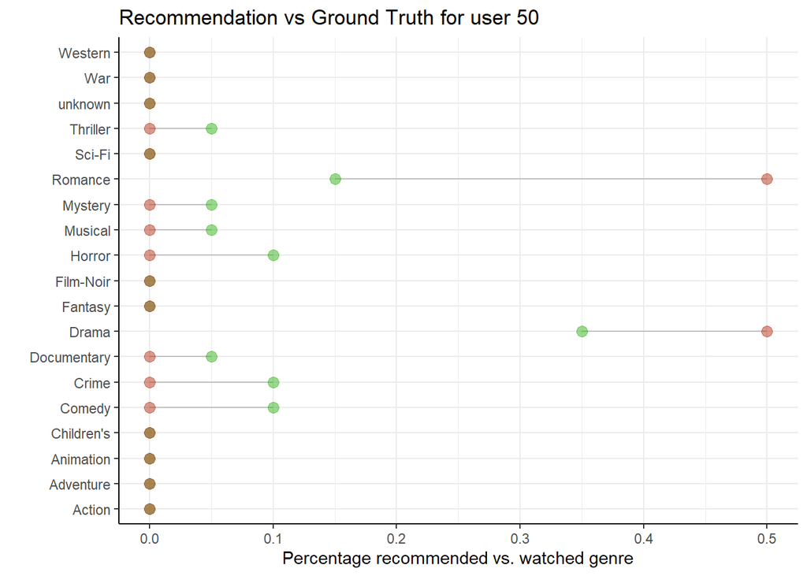

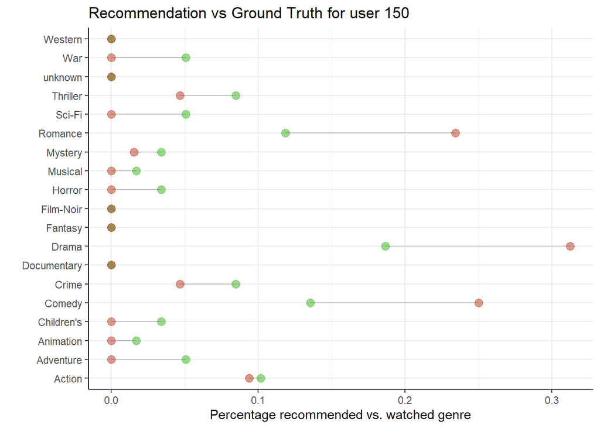

```r
user_profiles <-  analyze_topn_recos(top_top20_recos[top_top20_recos$Var2 %in% c(5, 25, 50, 150), ], 20)
create_cleveland_plot(user_profiles)
```

**Beschreibung:**

Rot sind unsere Top20-Recommendations und grün ist die Ground Truth. Wir sehen, dass für die User 5, 25, 50 und 150, Filme empfohlen bekommt mit Genres, welche der User über mehrere Filme als gut bewertet hat.

Aus der Distanz können wir auch den `mean squared error` bilden. Der MSE ist somit der Durchschnitt der `squared error` zwischen der Verteilung der geschauten Genres in Prozenten (ground truth) und der Verteilung der Genres der empfohlenen Filme in Prozenten. Es entspricht also der `squared distance` zwischen den grünen und roten Punkten im oberen Plot.

```r
squared_errors <- create_recomm_truth_MSE(user_profiles)
```

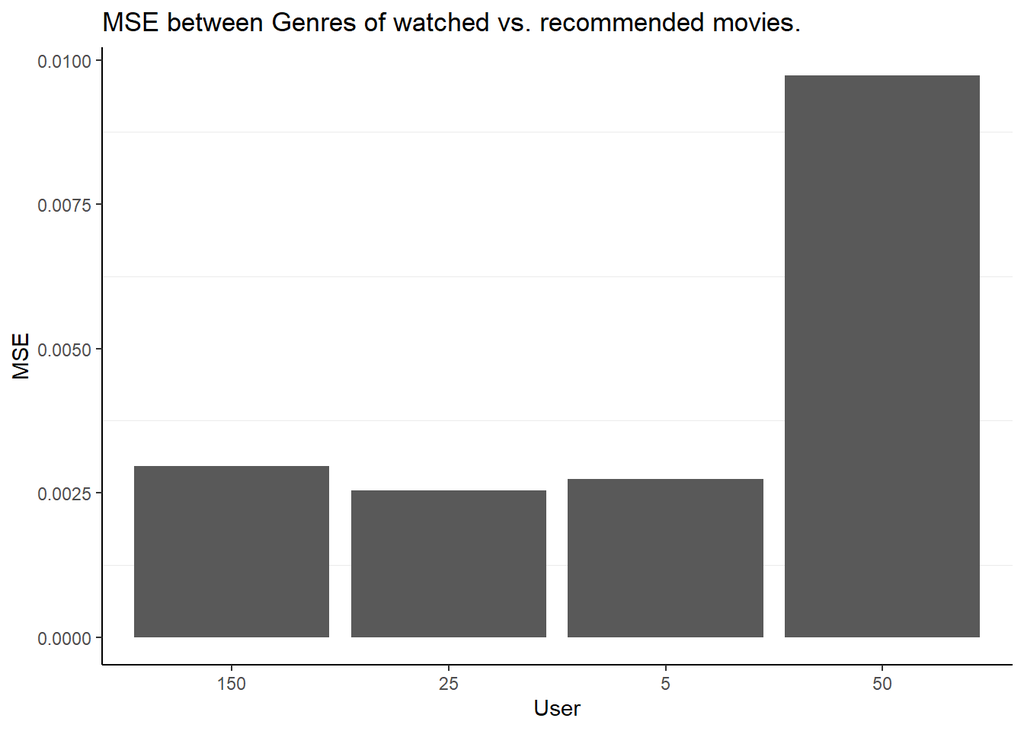

```r
p <-ggplot(data=squared_errors, aes(x=User, y=MSE)) +
  ggplot2::geom_bar(stat="identity") +
  ggplot2::labs(title = "MSE between Genres of watched vs. recommended movies.") +
  ggplot2::theme_bw() +
  ggplot2::theme(panel.border = element_blank(),
                 panel.grid.major = element_blank(),
                 axis.line = element_line(colour = "black"))

p
```

```r
mean(squared_errors$MSE)
```

```
## [1] 0.004495459
```

**Beschreibung:**

Wir sehen also, dass wir uns überall in einem kleinen Bereich aufhalten. Pro User und Genre hat es im Schnitt ca. einen MSE von 0.0045. Interessant ist der hohe Wert beim User 50.

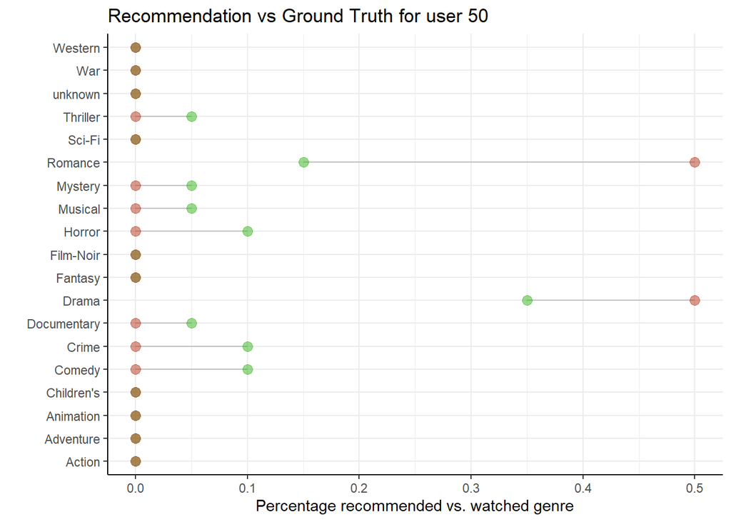

```r
user_profiles <-  analyze_topn_recos(top_top20_recos[top_top20_recos$Var2 %in% c(50), ], 20)
create_cleveland_plot(user_profiles)
```

**Beschreibung:**

Unser Recommender empfiehlt sehr oft Romances. Eine Vermutung ist, dass das Genre “Drama-Romance” sehr oft vorkommt. Da der User `50` Drama und Romances gut bewertet hat, schaut der Recommender, dass diese auch empfohlen werden. Wenn wir uns die Top20 Liste vom user `50` anschauen, sehen wir da auch nur “Drama-Romances”. Ebenfalls hat User `50` nur 20 Filme als gut bewertet, 7 davon in Drama und 3 davon in Romance. Somit bekommt er zuerst Filme empfohlen, welche diese beiden Genres auch beinhalten. Hier ist nun die Frage, ob es optimal ist, dass der User `50` nur Drama-Romances empfohlen bekommt.

```r
# Anzahl als gut Bewertete Filme pro Genre für den USer 50.
user_genre_mat[50,]
```

```
##     unknown      Action   Adventure   Animation  Children's      Comedy
##           0           0           0           0           0           2
##       Crime Documentary       Drama     Fantasy   Film-Noir      Horror
##           2           1           7           0           0           2
##     Musical     Mystery     Romance      Sci-Fi    Thriller         War
##           1           1           3           0           1           0
##     Western
##           0
```

### 4.7. Für Nutzer “133” und “555” Profil mit Top-N Empfehlungen für N = 20, 30, 40, 50 analysieren, visualisieren und diskutieren.

```r
top_n_intervall = c(20, 30, 40, 50)
top_n_col_names = c('Top 20', 'Top 30', 'Top 40', 'Top 50')
users = c(133, 555)
#create data frame with 0 rows and 5 columns
top_n_list_selected_users <- data.frame(matrix(ncol = 3, nrow = 0))

#provide column names
colnames(min_similarity_top_n) <- c('User', 'TopN', 'Similarity')
selected_users = similarity_users_melted[similarity_users_melted$Var2 %in% users,  ]

for (i in 1:4) {
  top_n_recos = get_topn_recos(selected_users, top_n_intervall[i])
  top_n_recos$User = top_n_recos$Var2
  top_n_recos$Similarity = top_n_recos$value
  top_n_recos$TopN = top_n_col_names[i]
  top_n_recos <- top_n_recos %>%
    select(User, TopN, Similarity) %>%
    arrange(desc(Similarity))
  top_n_list_selected_users <- rbind(top_n_list_selected_users,top_n_recos)
}
head(top_n_list_selected_users)
```

|  | User | TopN | Similarity |
| --- | --- | --- | --- |
| 1 | 133 | Top 20 | 0.8333333 |
| 2 | 133 | Top 20 | 0.8333333 |
| 3 | 133 | Top 20 | 0.8333333 |
| 4 | 133 | Top 20 | 0.8333333 |
| 5 | 133 | Top 20 | 0.8333333 |
| 6 | 133 | Top 20 | 0.8333333 |

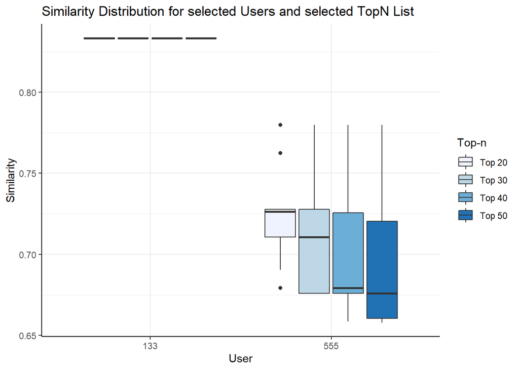

```r
ggplot2::ggplot(data = top_n_list_selected_users,
                ggplot2::aes(x = factor(User), y = Similarity, fill=factor(TopN))) +
  ggplot2::geom_boxplot() +
  ggplot2::scale_fill_brewer(palette = "Blues") +
  labs(title = "Similarity Distribution for selected Users and selected TopN List",
       fill = "Top-n") +
  ggplot2::theme_bw() +
  ggplot2::theme(panel.border = element_blank(),
                 axis.line = element_line()) +
  ggplot2::xlab("User")
```

**Beschreibung:**

Wir sehen, dass das Minimum der Similarities mit mehr Empfehlungen abnimmt. Dies ergibt auch Sinn, da die TopN-Empfehlungen die Filme empfiehlt, welche die höchste Genre-Similarity haben zu Filmen, welche man als gut bewertet hat. Somit werden bei einem höheren N auch Filme empfohlen mit einer niedrigeren Similarity. Hier muss man also aufpassen, dass man ein geschicktes N wählt: Ein User soll viele Filme empfohlen bekommen, welche aber auch für den User passen.

Eine Möglichkeit wäre, dass man das N von TopN pro User anhand einer mindest-Similarity berechnet. N soll man also so wählen, dass die tiefeste Similarity für den User nicht einen Threshold unterschreitet. Somit soll jeder User mindestens N Filme empfohlen bekommen, aber danach nur Filme, welche über dieser mindest-Similarity sind. Man könnte hierbei auch verschiedene Sets zur Offline-Evaluation verwenden und anhand von Top-N Metriken entscheiden, welche Threshold für User sich am besten eignen.

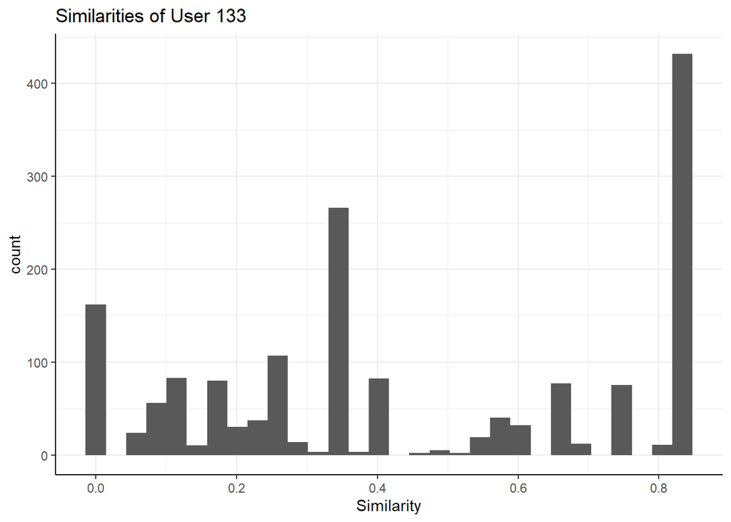

```r
user133 <- as.data.frame(similarity_users[133, ])
colnames(user133) <- c("Similarity")

ggplot2::ggplot(user133, ggplot2::aes(x = Similarity)) +
  ggplot2::geom_histogram() +
  ggplot2::theme_bw() +
  ggplot2::theme(panel.border = element_blank(),
                 axis.line = element_line()) +
  ggplot2::labs(title = "Similarities of User 133")
```

**Beschreibung:**

```r
top_50_user_133 = head(arrange(user133, desc(Similarity)), 50)
min(top_50_user_133)
```

```
## [1] 0.8333333
```

**Beschreibung:**

Unsere Annahme stimmt also; User `133` hat viele Similarites mit dem Wert `0.8333333` Da unsere Recommendations über Genres laufen, können wir uns anschauen, ob es da eine grosse Überschneidung gibt zwischen den Top50 Filmen und ihren Genres.

```r
top_50_user_133$title <- rownames(top_50_user_133)
top_50_user_133_genre <- left_join(top_50_user_133, movie_genre, by='title')
# Keep only columns which have at least one 1 in any row.
top_50_user_133_genre = top_50_user_133_genre[, colSums(top_50_user_133_genre == 1) > 0]
head(top_50_user_133_genre,10)
```

|  | Comedy | Drama |
| --- | --- | --- |
| 1 | 1 | 1 |
| 2 | 1 | 1 |
| 3 | 1 | 1 |
| 4 | 1 | 1 |
| 5 | 1 | 1 |
| 6 | 1 | 1 |
| 7 | 1 | 1 |
| 8 | 1 | 1 |
| 9 | 1 | 1 |
| 10 | 1 | 1 |

**Beschreibung:**

Ja, es stimmt! Die Top50 Resultate vom User 133 besteht nur aus dem Filmen mit dem Genre `Comedy` und `Drama` und zwar immer beide zusammen. Die `0.8333333` entsteht somit aus der Summe der Bewertungen pro Genre für den User `133` und der Genreverteilung dieser Top50-Filme.

Wir können die Cosine Similarity vom Film `Doom Generation, The (1995)` (Movie-ID 34) mit den Genres `Comedy` und `Drama` und dem User `133` und überprüfen, dass es `0.8333333` gibt.

```r
coop::cosine(user_genre_mat[133, ], movie_genre_mat[34, ])
```

```
## [1] 0.8333333
```

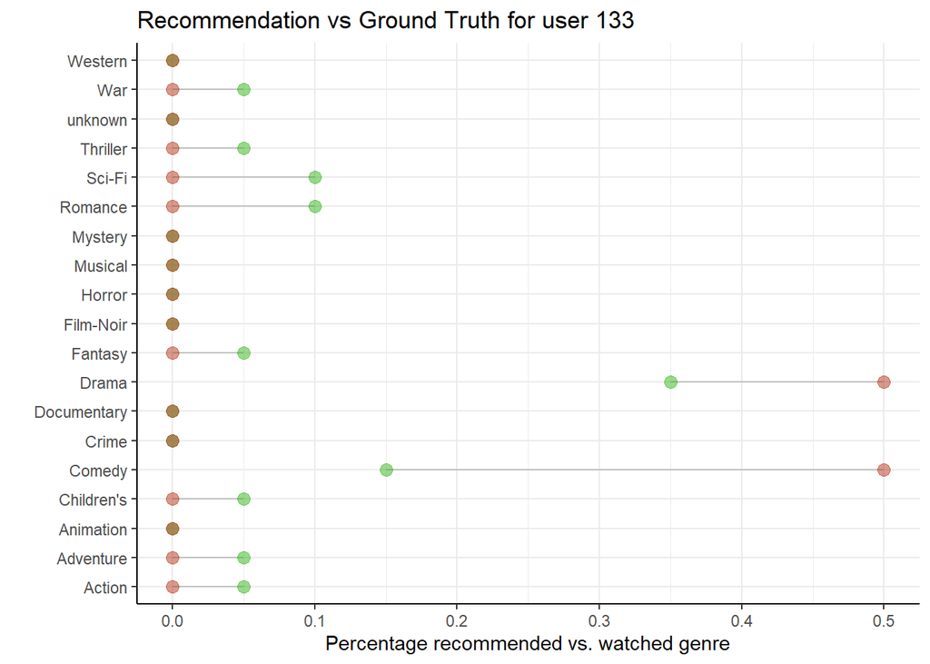

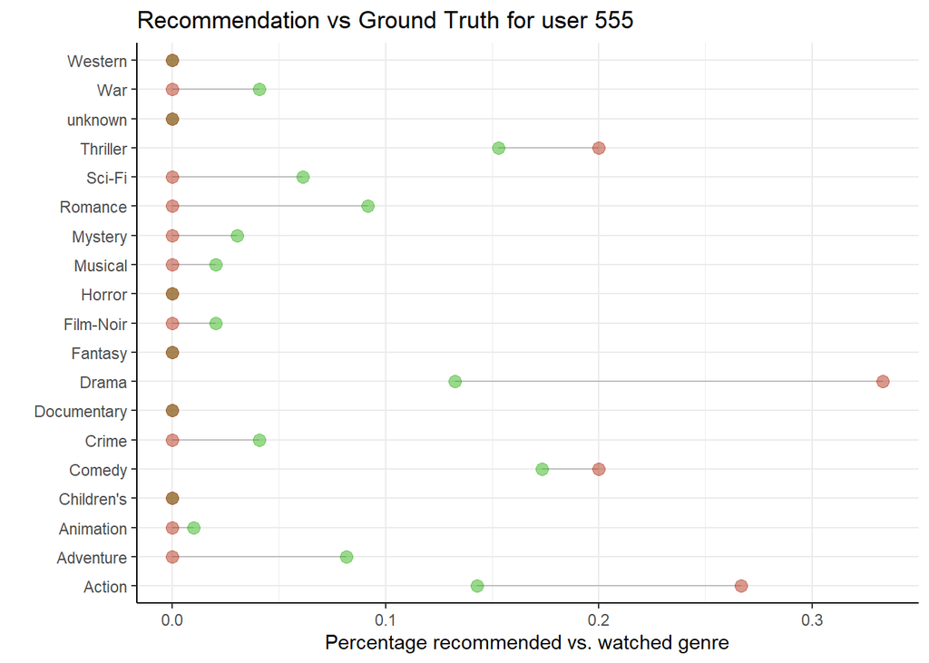

```r
user_profiles <-  analyze_topn_recos(selected_users, 5)
create_cleveland_plot(user_profiles)
```

**Beschreibung:**

Wir können für die Top20, 30, 40 und 50 (und noch mehr, damit wir das Verhalten des MSE besser verstehen) je den MSE über den User `133` und `555` berechnen.

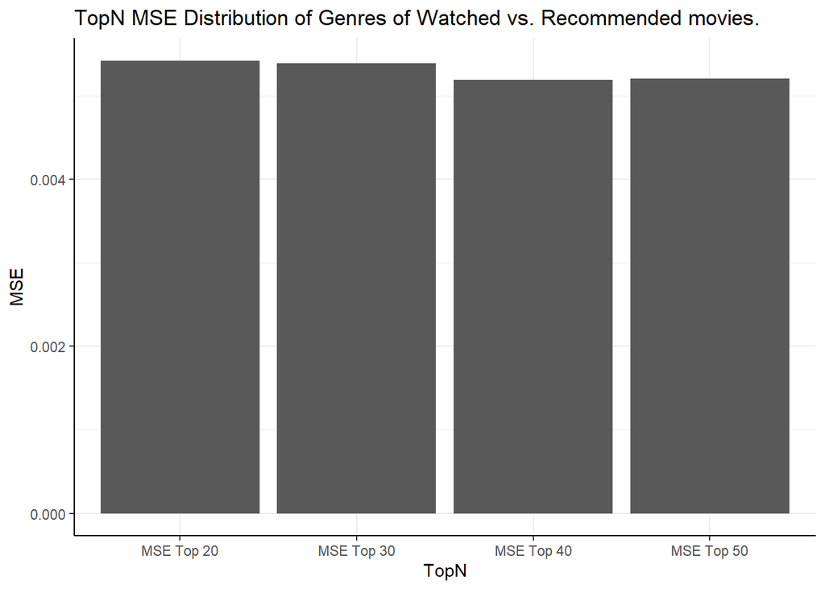

```r
top_n_intervall = c(20, 30, 40, 50)
top_n_col_names = c('MSE Top 20', 'MSE Top 30', 'MSE Top 40', 'MSE Top 50')
users = c(133, 555)
#create data frame with 0 rows and 5 columns
top_n_list_selected_users <- data.frame(matrix(ncol = 2, nrow = 0))


for (i in 1:length(top_n_col_names)) {
  top_n_recos <- analyze_topn_recos(similarity_users_melted[similarity_users_melted$Var2 %in% users, ],  top_n_intervall[i])
  top_n_recos <- create_recomm_truth_MSE(top_n_recos)
  top_n_recos$TopN <- top_n_col_names[i]
  top_n_recos <- top_n_recos %>%
    group_by(TopN) %>%
    summarise(MSE = mean(MSE))

  top_n_list_selected_users <- rbind(top_n_list_selected_users, top_n_recos)
}

p<-ggplot(data=top_n_list_selected_users, aes(x=TopN, y=MSE)) +
  ggplot2::geom_bar(stat="identity") +
  ggplot2::labs(title = "TopN MSE Distribution of Genres of Watched vs. Recommended movies.") +
  ggplot2::theme_bw() +
  ggplot2::theme(panel.border = element_blank(),
                 axis.line = element_line())

p
```

**Beschreibung:**

Wir sehen, dass der MSE ca. leicht abnimmt, wenn das N von TopN grösser wird. Dies lässt sich dadurch erklären, dass es nicht immer eine perfekte Genre-Verteilung gibt für eine TopN-Liste. Desto mehr Möglichkeiten der Recommender hat, Empfehlungen zu machen, desto mehr nähert sich die Verteilung der Genres vom Recommender an die perfekte Genre-Verteilung des Users an. Falls aber das N zu gross wird, nimmt der Fehler zu, da der Recommender nur noch Filme empfehlen kann, welche gar keine Überschneidung haben mit den “Lieblingsgenres” der Benutzer. Wir können uns das hier anschauen:

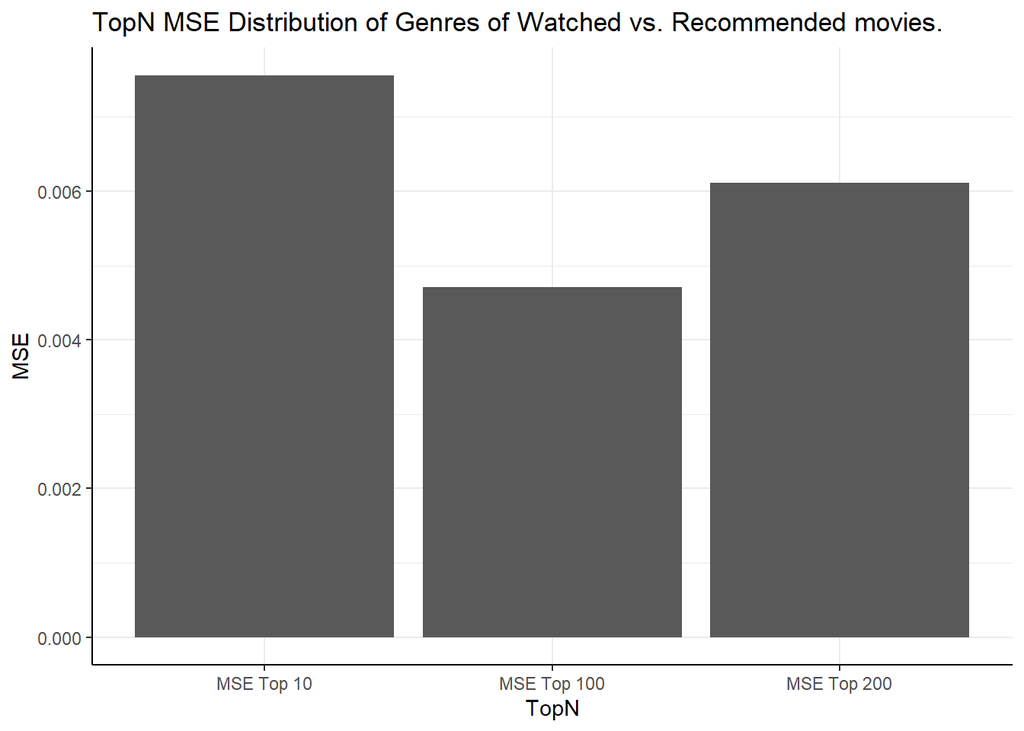

```r
top_n_intervall = c(10, 100, 200)
top_n_col_names = c('MSE Top 10', 'MSE Top 100', 'MSE Top 200')
users = c(133, 555)
#create data frame with 0 rows and 5 columns
top_n_list_selected_users <- data.frame(matrix(ncol = 2, nrow = 0))


for (i in 1:length(top_n_col_names)) {
  top_n_recos <- analyze_topn_recos(similarity_users_melted[similarity_users_melted$Var2 %in% users, ],  top_n_intervall[i])
  top_n_recos <- create_recomm_truth_MSE(top_n_recos)
  top_n_recos$TopN <- top_n_col_names[i]
  top_n_recos <- top_n_recos %>%
    group_by(TopN) %>%
    summarise(MSE = mean(MSE))

  top_n_list_selected_users <- rbind(top_n_list_selected_users, top_n_recos)
}

p<-ggplot(data=top_n_list_selected_users, aes(x=TopN, y=MSE)) +
  ggplot2::geom_bar(stat="identity") +
  ggplot2::labs(title = "TopN MSE Distribution of Genres of Watched vs. Recommended movies.") +
  ggplot2::theme_bw() +
  ggplot2::theme(panel.border = element_blank(),
                 axis.line = element_line())
p
```

**Beschreibung:**

Interessanterweise hat es also ein Minimum für den MSE. Daraus liesse sich theoretischerweise ein optimales N pro User erstellen.

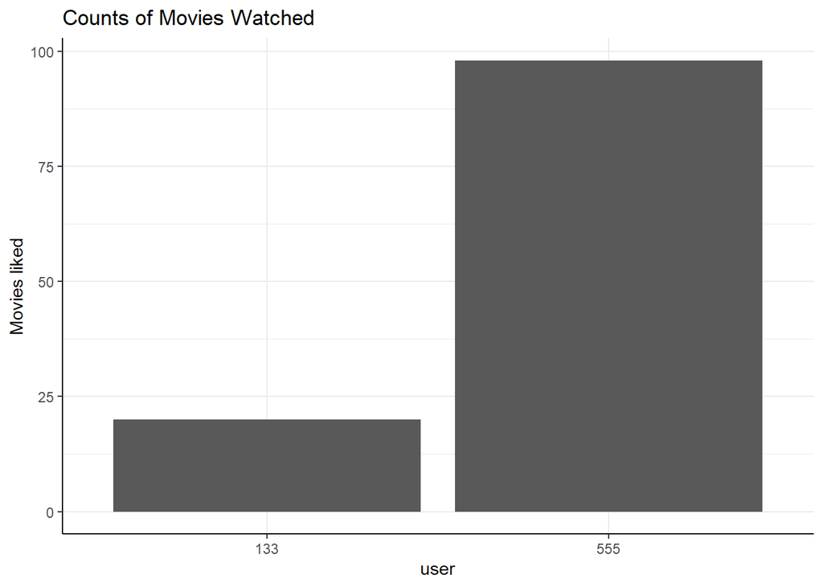

```r
user_profiles <-  analyze_topn_recos(selected_users, 50)
user_profiles <- user_profiles[1:2, ] %>%
  select(-c(ground_truth, user))
user_watched_total <- as.data.frame(rowSums(user_profiles))
user_watched_total$user <- rownames(user_watched_total)
row.names(user_watched_total) <- NULL
colnames(user_watched_total) <- c("liked", "user")

ggplot2::ggplot(user_watched_total, aes(x = user, y = liked)) +
  geom_col() +
  ggplot2::theme_bw() +
  ggplot2::theme(panel.border = element_blank(),
                 axis.line = element_line()) +
  ggplot2::labs(title = "Counts of Movies Watched") +
  ggplot2::ylab("Movies liked")
```

**Beschreibung:**

Wenn wir einen Vergleich der Anzahl der Filme machen, die die User geliked haben, können wir auch feststellen, dass viel weniger Informationen über die Präferenz des Nutzers 133 vorhanden ist. Dies hat zur Folge, dass weniger Informationen in unser Recommender System als Input geliefert werden, deshalb vermuten wir, dass darum eher grössere Abweichungen zwischen dem empfohlenen Profil zum tatsächlich gesehenen Profil erkennbar sind. Ebenfalls wird duch diese wenigen guten Bewertungen das genre-Profil" von User 133 sehr einseitig.

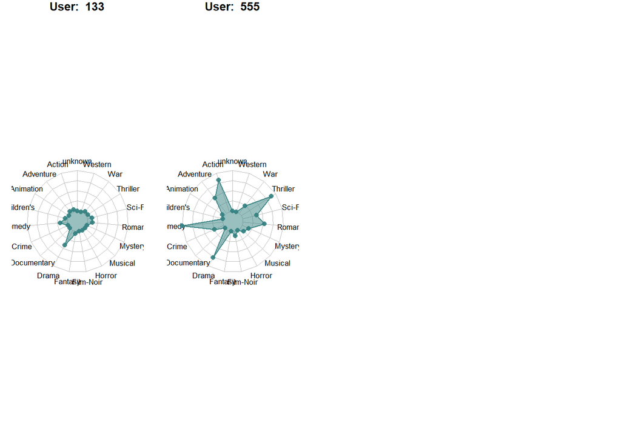

```r
# Create Binaray User-Genre Matrix
plot_user_profiles(user_genre_mat, user_idx = c(133, 555),
                    sample_size = 4)
```

**Beschreibung:**

Das “genre-Profil” vom User `133` ist weniger ausgeprägt als vom User 555, da es nur “Spitzen” im Radarplot bei Drama und Comedy hat.

#### © Copyright 2022 Vincenzo Timmel, Simon Staehli, Firat Saritas

Permission is hereby granted, free of charge, to any person obtaining a copy of this software and associated documentation files (the “Software”), to deal in the Software without restriction, including without limitation the rights to use, copy, modify, merge, publish, distribute, sublicense, and/or sell copies of the Software, and to permit persons to whom the Software is furnished to do so, subject to the following conditions:

The above copyright notice and this permission notice shall be included in all copies or substantial portions of the Software.

THE SOFTWARE IS PROVIDED “AS IS”, WITHOUT WARRANTY OF ANY KIND, EXPRESS OR IMPLIED, INCLUDING BUT NOT LIMITED TO THE WARRANTIES OF MERCHANTABILITY, FITNESS FOR A PARTICULAR PURPOSE AND NONINFRINGEMENT. IN NO EVENT SHALL THE AUTHORS OR COPYRIGHT HOLDERS BE LIABLE FOR ANY CLAIM, DAMAGES OR OTHER LIABILITY, WHETHER IN AN ACTION OF CONTRACT, TORT OR OTHERWISE, ARISING FROM, OUT OF OR IN CONNECTION WITH THE SOFTWARE OR THE USE OR OTHER DEALINGS IN THE SOFTWARE.